# ReneWind

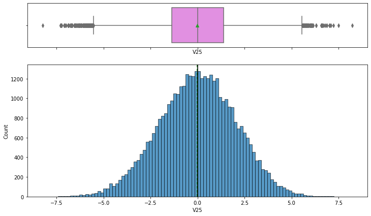

```python
histogram_boxplot(df, "V25")
```

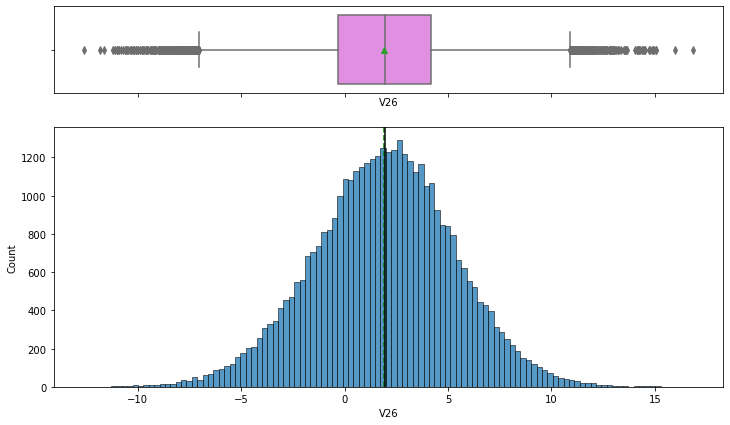

```python
histogram_boxplot(df, "V26")
```

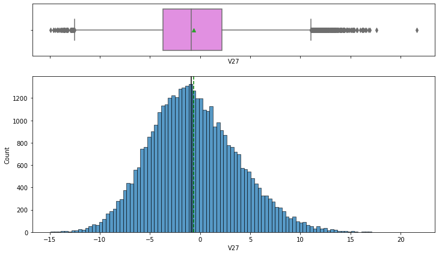

```python
histogram_boxplot(df, "V27")
```

```python
df[df["V27"] > 18]
```

|  | V1 | V2 | V3 | V4 | V5 | V6 | V7 | V8 | V9 | V10 | V11 | V12 | V13 | V14 | V15 | V16 | V17 | V18 | V19 | V20 | V21 | V22 | V23 | V24 | V25 | V26 | V27 | V28 | V29 | … |
| --- | --- | --- | --- | --- | --- | --- | --- | --- | --- | --- | --- | --- | --- | --- | --- | --- | --- | --- | --- | --- | --- | --- | --- | --- | --- | --- | --- | --- | --- | --- |
| 27202 | 12.364 | -2.878 | 11.250 | -16.015 | -4.352 | 0.227 | 2.690 | -1.799 | -2.234 | 5.920 | 3.715 | 4.503 | 9.835 | 2.196 | 2.638 | 0.426 | -17.634 | -1.763 | -2.444 | -10.156 | -7.393 | -0.058 | -7.607 | -12.272 | 5.454 | 4.823 | 21.595 | -9.685 | -3.756 | … |

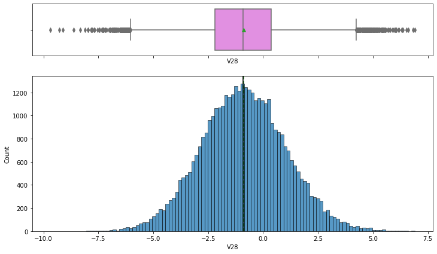

```python
histogram_boxplot(df, "V28")
```

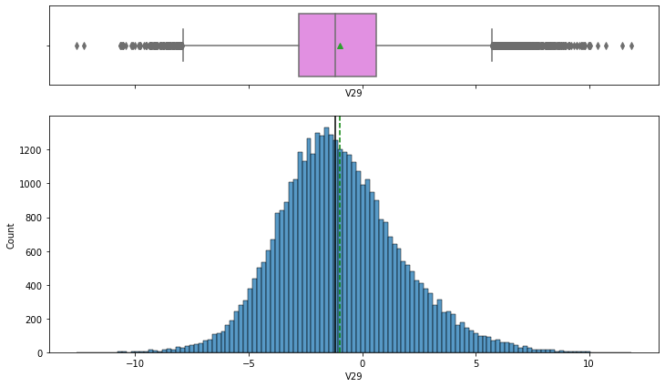

```python
histogram_boxplot(df, "V29")
```

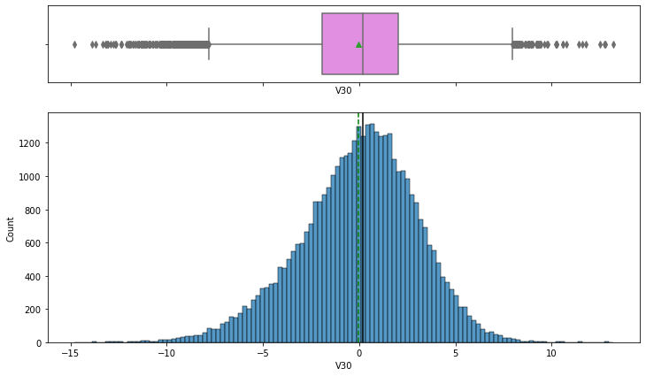

```python
histogram_boxplot(df, "V30")
```

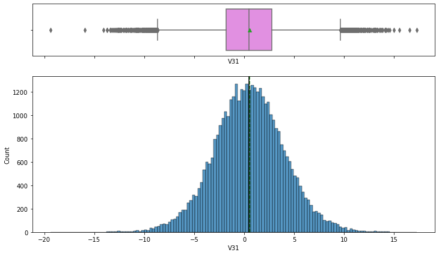

```python
histogram_boxplot(df, "V31")
```

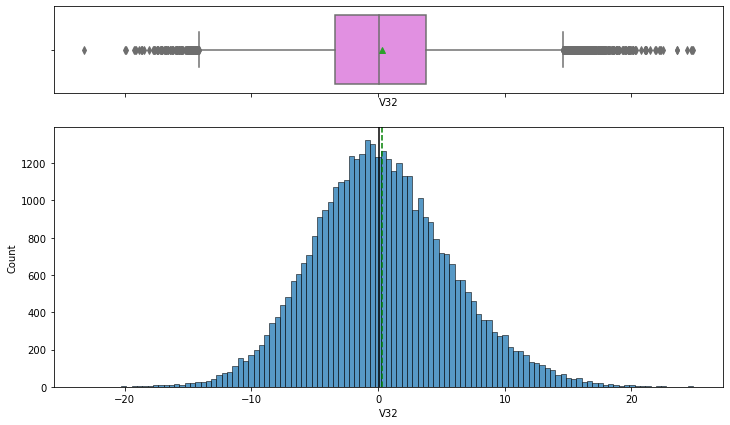

```python
histogram_boxplot(df, "V32")
```

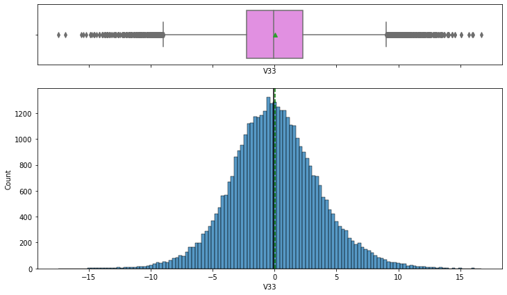

```python
histogram_boxplot(df, "V33")
```

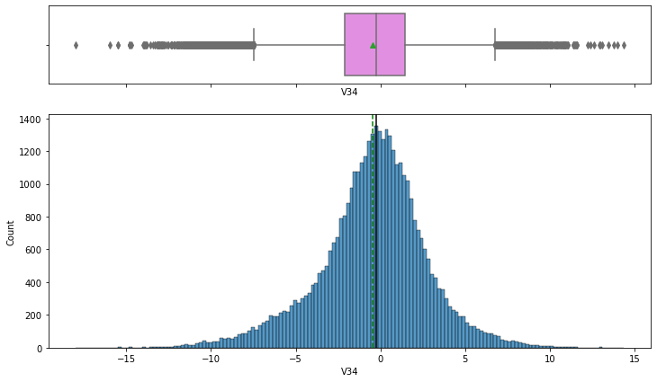

```python
histogram_boxplot(df, "V34")
```

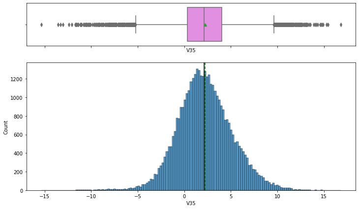

```python
histogram_boxplot(df, "V35")
```

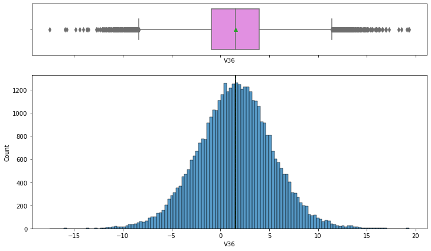

```python
histogram_boxplot(df, "V36")
```

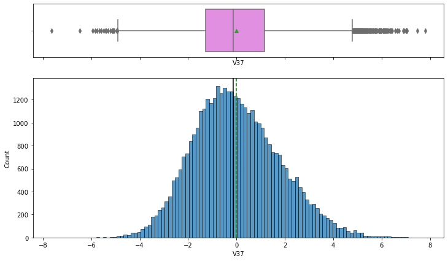

```python
histogram_boxplot(df, "V37")
```

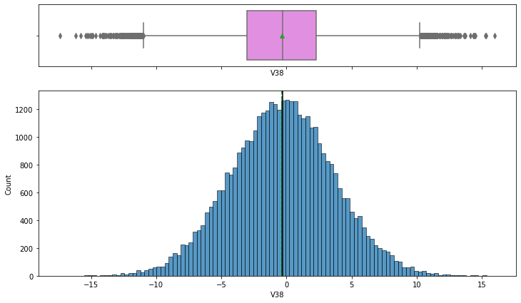

```python
histogram_boxplot(df, "V38")
```

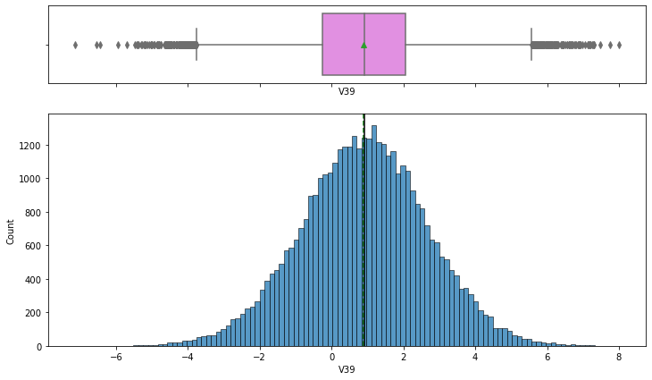

```python
histogram_boxplot(df, "V39")
```

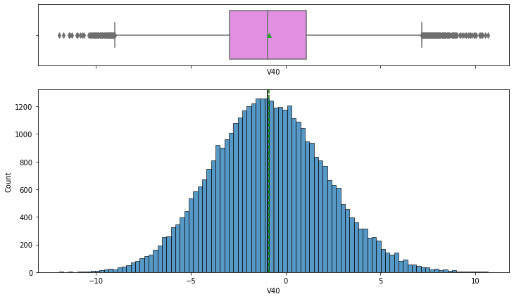

```python
histogram_boxplot(df, "V40")
```

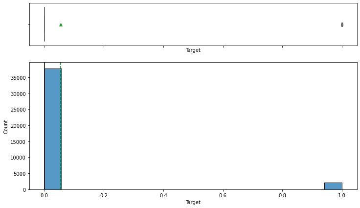

```python
histogram_boxplot(df, "Target")
```

```python
# sns.pairplot(df, hue="Target")
```

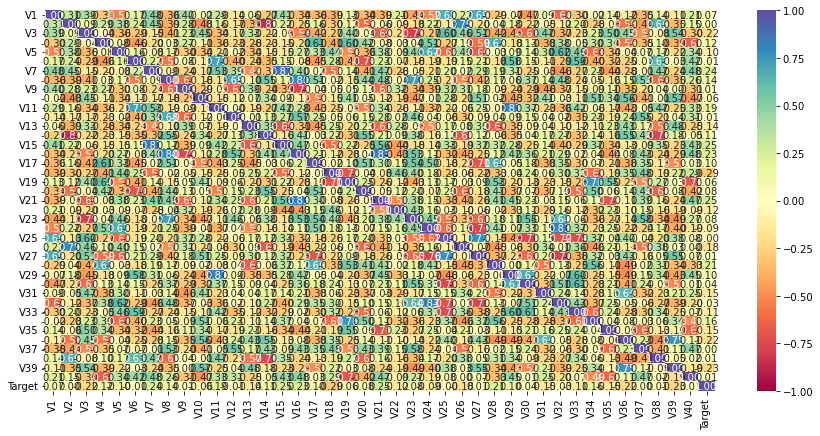

```python
plt.figure(figsize=(15, 7))
sns.heatmap(df.corr(), annot=True, vmin=-1, vmax=1, fmt=".2f", cmap="Spectral")
plt.show()
```

## Data Pre-processing

### Split the data

```python
X = df.drop(["Target"], axis=1)
y = df["Target"]
```

```python
# first we split data into 2 parts, say temporary and test

X_temp, X_test, y_temp, y_test = train_test_split(
    X, y, test_size=0.2, random_state=1, stratify=y
)

# then we split the temporary set into train and validation

X_train, X_val, y_train, y_val = train_test_split(
    X_temp, y_temp, test_size=0.25, random_state=1, stratify=y_temp
)
print(X_train.shape, X_val.shape, X_test.shape)
```

```
(24000, 40) (8000, 40) (8000, 40)
```

```python
df.info()
```

```
<class 'pandas.core.frame.DataFrame'>
RangeIndex: 40000 entries, 0 to 39999
Data columns (total 41 columns):
 #   Column  Non-Null Count  Dtype
---  ------  --------------  -----
 0   V1      39954 non-null  float64
 1   V2      39961 non-null  float64
 2   V3      40000 non-null  float64
 3   V4      40000 non-null  float64
 4   V5      40000 non-null  float64
 5   V6      40000 non-null  float64
 6   V7      40000 non-null  float64
 7   V8      40000 non-null  float64
 8   V9      40000 non-null  float64
 9   V10     40000 non-null  float64
```

[output cut: 33 more lines]

```python
reqd_col_for_impute = [
    [
        "V1",
        "V2",
        "V3",
        "V4",
        "V5",
        "V6",
        "V7",
        "V8",
        "V9",
        "V10",
        "V11",
        "V12",
        "V13",
        "V14",
        "V15",
        "V16",
        "V17",
        "V18",
        "V19",
        "V20",
        "V21",
        "V22",
        "V23",
        "V24",
        "V25",
        "V26",
        "V27",
        "V28",
        "V29",
        "V30",
        "V31",
        "V32",
        "V33",
        "V34",
        "V35",
        "V36",
        "V37",
        "V38",
        "V39",
        "V40","
    ]
]
imputer = SimpleImputer(missing_values=np.nan, strategy="median")

# Fit and transform the train data
X_train[reqd_col_for_impute] = imputer.fit_transform(X_train[reqd_col_for_impute])

# Transform the validation data
X_val[reqd_col_for_impute] = imputer.transform(X_val[reqd_col_for_impute])

# Transform the test data
X_test[reqd_col_for_impute] = imputer.transform(X_test[reqd_col_for_impute])
```

[output not shown]

[output not shown]

```python
df.isnull().sum()
```

[output not shown]

## Model evaluation criterion

### 3 types of cost are associated with the provided problem

1. Replacement cost - False Negatives - Predicting no failure, while there will be a failure
2. Inspection cost - False Positives - Predicting failure, while there is no failure
3. Repair cost - True Positives - Predicting failure correctly

### How to reduce the overall cost?

- We need to create a customized metric, that can help to bring down the overall cost.
- The cost associated with any model = TP *15000 + FP* 5000 + FN * 40000
- And the minimum possible cost will be when, the model will be able to identify all failures, in that case, the cost will be (TP + FN) * 15000
- So, we will try to maximize `Minimum cost/Cost associated with model`

```python
df.info()
```

[output not shown]